# Dynamic Report - TFM

Marta Sanchez Delgado

6 de junio, 2018

# 1 Initial instructions

## 1.1 Downloading expression file from GTEx

The first step to correctly generate all expression information from your initial coordinates is to download the **`GTEx_Analysis_2016-01-15_v7_RNASeQCv1.1.8_gene_median_tpm.gct`** file from: https://gtexportal.org/home/datasets. Gene expression on the GTEx Portal are shown in Transcripts per Million (TPM), and the samples come from the 1000 genomes project. The downloaded file contains median gene counts (in TPM) by tissue (53 in total).

## 1.2 General instructions to update input file

All R-scripts are in the first part of the document **`Scripts-TFM.R`**. However, the corresponding **`Dynamic report-TFM.Rmd`** can be used to generate the new set of output files automatically.

Now all the output files and all the information on `Dynamic report-TFM` documents will be generated with your new .csv data-table named NUMTs_coord.csv.

The following pages will be generated with the new information. Now you have all data, statistics and tables updated with the coordinates in document NUMTs_coord.csv.

# 2 Context

The following scripts were generated for the final master’s project in Bioinformatics and Biostatistics (*Universitat Oberta de Catalunya*) entitle *Are Nuclear Insertions of Mitochondrial Origin Pseudogenes?*.

This Master’s project focussed on the study of Nuclear mitochondrial DNA sequences (NUMTs). NUMTs are the result of a continuous DNA transfer from mitochondria to the nucleus (Boogaart, Samallo, and Agsteribbe 1982; Tsuzuki et al. 1983).

In 2011, in a published work led by Dr Cristina Santos, it was identified 755 NUMTs in the human genome (Ramos et al. 2011). They compared the human mtDNA (NC_012920) against human genome (GRCh37/hg19 assembly), and they described different aspects of this comparisons: frequency, distribution and size of NUMTs for each chromosome; % identity between NUMTs and mtDNA sequence… Based on this information and **NUMTs coordinates**, in the present master’s final project, we want to clarify whether or not these NUMTs origin pseudogenes.

# 3 Visualization of NUMTs in UCSC genome browser

First of all, with the NUMTs coordinates publically available by Ramos et al. (2011), we created the file `bed_NUMTs-ID.txt`, which can be uploaded to *UCSC genome browser –> custom track* to visualise our NUMTs.

The `bed_NUMTs-ID.txt` also include the corresponding mitochondrial regions for each NUMT, with the same NUMT ID by adding “mt” in the beginning.

# 4 Installing only packages we need

Depending on the computer and session, we already have some R packages installed. To install only the ones we need we will use the following script:

```r
######## PART 1: Scripts from Dynamic_report_TFM.Rmd ##########

# Installing package if needed ----
list.of.packages <- c("rstudioapi", "dplyr", "xlsx", "rJava", "gplots",
                      "devtools", "ggplot2")
new.packages <- list.of.packages[!(list.of.packages %in%
                                     installed.packages()[,"Package"])]
if(length(new.packages)) install.packages(new.packages)
```

However, to generate our data, we also need to download special packages from Bioconductor:

# 5 Input file format

The document must be .csv with `comma (",")` separator, which is the one automatically used in most programmes like Excel or LibreOffice Calc when we save the data as .csv. The first line of the document will be the **Column names**. The First column will name as `id` (with any ID you wanted to use), second column `chr` (with the number of the corresponding chromosome), third `start_n` with the starting bp coordinate and then `end_n` with the end pb coordinate. The last three columns will be additional information. In the case of the original document created for this final master’s project corresponds to the coordinates mapping these regions in the mitochondrial: 6th column entitle `mt` and in all cases “mt” because is how mitochondrial DNA is recognised, and then both, initial `start_mt` and final `end_mt` coordinates in the mitochondrial DNA.

```
## 'data.frame':    756 obs. of  7 variables:
##  $ id      : Factor w/ 756 levels "NUMT_01.001",..: 1 2 ...
##  $ chr     : Factor w/ 24 levels "1","10","11",..: 1 1 ...
##  $ start_n : int  564461 5614806 ...
##  $ end_n   : int  570304 5614937 ...
##  $ mt      : Factor w/ 1 level "mt": 1 1 ...
##  $ start_mt: int  3911 9453 ...
##  $ end_mt  : int  9755 9583 ...
```

```
##            id chr  start_n    end_n mt start_mt end_mt
## 1 NUMT_01.001   1   564461   570304 mt     3911   9755
## 2 NUMT_01.002   1  5614806  5614937 mt     9453   9583
## 3 NUMT_01.003   1  5910318  5910528 mt     2466   2675
## 4 NUMT_01.004   1  8969802  8969967 mt     8040   8205
## 5 NUMT_01.005   1  9634687  9634887 mt      907   1117
## 6 NUMT_01.006   1 11202904 11202975 mt    12293  12358
```

The file NUMTs_coord.csv contains a total of 756 rows with coordinates.

# 6 All intermediate files and the final table

## 6.1 File 1 and 2: “All_attributes.txt” & “All_filters.txt”

To download the list of genes within our initial coordinates and its associated phenotype description, gene ontology (GO) and conservation in other species, we use `biomaRt` package from `Bioconductor`:

### 6.1.1 The `biomaRt` package

```
##
##
##   Mapping identifiers for the integration of genomic datasets with
##   the R/Bioconductor package biomaRt. Steffen Durinck, Paul T.
##   Spellman, Ewan Birney and Wolfgang Huber, Nature Protocols 4,
##   1184-1191 (2009).
##
##   BioMart and Bioconductor: a powerful link between biological
##   databases and microarray data analysis. Steffen Durinck, Yves
##   Moreau, Arek Kasprzyk, Sean Davis, Bart De Moor, Alvis Brazma
##   and Wolfgang Huber, Bioinformatics 21, 3439-3440 (2005).
##
## To see these entries in BibTeX format, use 'print(<citation>,
## bibtex=TRUE)', 'toBibtex(.)', or set
## 'options(citation.bibtex.max=999)'.
```

### 6.1.2 Preparing Package ‘biomaRt’

It is automatically generated the first two files: `All_attributes.txt` (with all attributes you can download with `biomaRt` package) and `All_filters.txt` (with all `filters` to select the information to use from your input file).

The dimensions of File 1 are: 1416, 3 and the dimensions of File 2: 303, 2

## 6.2 File 3: “gene_results.txt”

Filtering by our initial coordinates, we create the file `gene_results.txt` with all genes which coordinates and our initial coordinates overlaps partially or totally.

```
##            id       chromosome_name start_position
##  NUMT_04.035:  11   2      :153     Min.   :   536816
##  NUMT_05.022:  11   7      : 70     1st Qu.: 38039816
##  NUMT_02.043:  10   X      : 63     Median : 80736542
##  NUMT_01.001:   8   1      : 59     Mean   : 86166624
##  NUMT_02.058:   8   4      : 58     3rd Qu.:120972370
##  NUMT_05.030:   8   (Other):511     Max.   :240713167
##  (Other)    :1099   NA's   :241     NA's   :241
##   end_position           strand            hgnc_symbol
##  Min.   :   564813   Min.   :-1.00000   MLPH     : 17
##  1st Qu.: 38078249   1st Qu.:-1.00000   LINC00630: 13
##  Median : 80925878   Median : 1.00000   LINC00882:  7
##  Mean   : 86268873   Mean   : 0.03939   ZNF540   :  7
##  3rd Qu.:120974671   3rd Qu.: 1.00000   ZNF571   :  7
##  Max.   :240775449   Max.   : 1.00000   (Other)  :480
##  NA's   :241         NA's   :241        NA's     :624
##        ensembl_gene_id_version        ensembl_gene_id transcript_count
##  ENSG00000115648.9 : 17        ENSG00000115648: 17    Min.   : 1.000
##  ENSG00000223546.2 : 13        ENSG00000223546: 13    1st Qu.: 1.000
##  ENSG00000171817.12:  7        ENSG00000171817:  7    Median : 1.000
##  ENSG00000180479.9 :  7        ENSG00000180479:  7    Mean   : 3.953
##  ENSG00000242759.2 :  7        ENSG00000242759:  7    3rd Qu.: 5.000
##  (Other)           :863        (Other)        :863    Max.   :32.000
##  NA's              :241        NA's           :241    NA's   :241
```

The dimensions of File 3 are: 1155, 9

In total, `gene_results.txt` contains 733 genes and 241/756 NUMTs do not overlap with any gene.

## 6.3 File 4 and 5: “up_gene_results.txt” and “down_gene_results.txt”

Genes in `gene_results.txt` also includes large gene coding proteins where the NUMTs are probably located in intronic regions. To eliminate this genes, an additional two other lists were generated with new coordinates obtained from the upstream or downstream part of the original NUMTs coordinates (between 100 - 1000 bp from the initial coordinates). Once we get this two new list of genes associated to different NUMTs, we eliminate from the initial list in `gene_results.txt` that genes also present upstream AND downstream the initial coordinates. However, we ALWAYS associated gene with NUMTs, and also those genes associated to specific NUMT is eliminate (to conserve genes which includes more than one NUMT).

```
## 'data.frame':    891 obs. of  9 variables:
##  $ id                     : Factor w/ 756 levels "NUMT_01.001",..: 1 1 ...
##  $ chromosome_name        : Factor w/ 24 levels "1","10","11",..: 1 1 ...
##  $ start_position         : int  536816 562757 ...
##  $ end_position           : int  659930 564390 ...
##  $ strand                 : int  -1 -1 ...
##  $ hgnc_symbol            : Factor w/ 275 levels "ABCA8","ACSM3",..: NA NA ...
##  $ ensembl_gene_id_version: Factor w/ 414 levels "ENSG00000003400.10",..: 262 213 ...
##  $ ensembl_gene_id        : Factor w/ 414 levels "ENSG00000003400",..: 262 213 ...
##  $ transcript_count       : int  5 1 ...
```

```
## 'data.frame':    905 obs. of  9 variables:
##  $ id                     : Factor w/ 756 levels "NUMT_01.001",..: 1 2 ...
##  $ chromosome_name        : Factor w/ 24 levels "1","10","11",..: 1 NA ...
##  $ start_position         : int  536816 NA ...
##  $ end_position           : int  659930 NA ...
##  $ strand                 : int  -1 NA ...
##  $ hgnc_symbol            : Factor w/ 274 levels "ABCA8","ACSM3",..: NA NA ...
##  $ ensembl_gene_id_version: Factor w/ 425 levels "ENSG00000003400.10",..: 264 NA ...
##  $ ensembl_gene_id        : Factor w/ 425 levels "ENSG00000003400",..: 264 NA ...
##  $ transcript_count       : int  5 NA ...
```

In the upstream part of NUMTs coordinates we find 414 and in the downstream region 425 genes. Once we have the three list of genes, we wanted to compare all of them and select the ones originated by a NUMT insertion.

The dimensions of File 4 are: 891, 9 and the dimensions of File 5: 905, 9

## 6.4 File 6: “genes.txt”

The distribution of the genes within NUMTs in the different chromosomes is:

```
##
##  1 10 11 12 13 14 15 16 17 18 19  2 20 21 22  3  4  5  6  7  8  9  X  Y
## 45 16 14  4  8  5  9 13 18  2  3 81  5  4  8 24 36 32 16 39 19 23 28  5
```

Of the 733 initial genes, after our filtering, we have 457 genes within the initial input coordinates.

The dimensions of File 6 are: 457, 1

## 6.5 File 7: “go_results.txt”

```
##    hgnc_symbol ensembl_gene_id_version      go_id
## 1     ARHGAP15       ENSG00000075884.8 GO:0005622
## 2     ARHGAP15       ENSG00000075884.8 GO:0005829
## 3     ARHGAP15       ENSG00000075884.8 GO:0007165
## 4     ARHGAP15       ENSG00000075884.8 GO:0007264
## 5     ARHGAP15       ENSG00000075884.8 GO:0008360
## 6     ARHGAP15       ENSG00000075884.8 GO:0016020
## 7     ARHGAP15       ENSG00000075884.8 GO:0030675
## 8     ARHGAP15       ENSG00000075884.8 GO:0032855
## 9     ARHGAP15       ENSG00000075884.8 GO:0051056
## 10    MTRNR2L4       ENSG00000232196.2 GO:0005576
## 11    MTRNR2L4       ENSG00000232196.2 GO:0005737
## 12    MTRNR2L5       ENSG00000249860.2 GO:0005576
## 13    MTRNR2L5       ENSG00000249860.2 GO:0005737
## 14    MTRNR2L9       ENSG00000255633.3 GO:0005576
```

[output cut: 49 more lines]

Only 12 of the 457 genes originated by NUMTs insertion are anotated in [Gene Ontology Consortium](http://www.geneontology.org/). However, as we can see in Figure 3, they are associated with different GO terms.

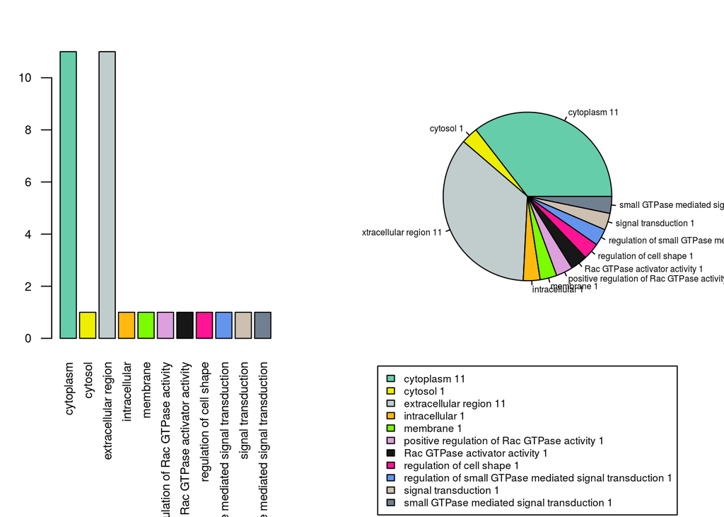

GO terms annotated for our list of genes.

The dimensions of File 7 are: 31, 5

## 6.6 File 8: “phenotype_results.txt”

```
##    hgnc_symbol       ensembl_gene_id_version transcript_count
##  MIR4461 :  2   ENSG00000075884.8:  1        Min.   : 1.000
##  ARHGAP15:  1   ENSG00000198744.5:  1        1st Qu.: 1.000
##  MIR4484 :  1   ENSG00000198868.3:  1        Median : 1.000
##  MTATP6P1:  1   ENSG00000216713.1:  1        Mean   : 1.031
##  MTATP6P2:  1   ENSG00000216853.1:  1        3rd Qu.: 1.000
##  (Other) :183   ENSG00000217044.1:  1        Max.   :14.000
##  NA's    :268   (Other)          :451
##          gene_biotype
##  antisense     :  1
##  lincRNA       :  1
##  miRNA         :  4
##  protein_coding: 14
##  pseudogene    :436
##  snRNA         :  1
##
##                                                                              description
##  microRNA 4461 [Source:HGNC Symbol;Acc:41656]                                      :  2
##  hsa-mir-6723 [Source:miRBase;Acc:MI0022558]                                       :  1
##  microRNA 4484 [Source:HGNC Symbol;Acc:41799]                                      :  1
##  mitochondrially encoded ATP synthase 6 pseudogene 1 [Source:HGNC Symbol;Acc:44575]:  1
##  mitochondrially encoded ATP synthase 6 pseudogene 2 [Source:HGNC Symbol;Acc:44576]:  1
##  (Other)                                                                           :184
##  NA's                                                                              :267
```

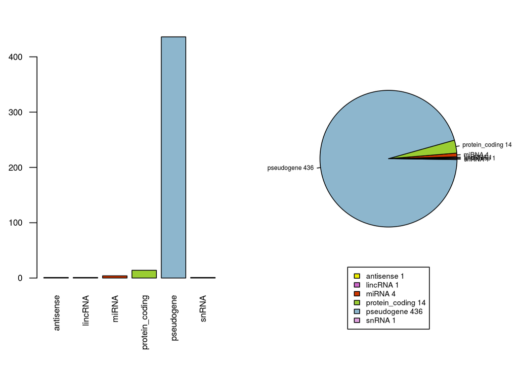

Gene biotype annotated for our list of genes.

In this case, all genes within our NUMTs are classified in ensembl-Biotype

The dimensions of File 8 are: 457, 5

## 6.7 File 9: “mean_tpm_GTEx.txt”

We then search in `GTEx_Analysis_2016-01-15_v7_RNASeQCv1.1.8_gene_median_tpm.gct` document our list of genes included in `genes.txt`.

Initially, we save all data existing for all our genes and calculate the mean and total TGM per gene.

The dimensions of File 9 are: 453, 58

## 6.8 File 10: “subset_expressed.txt”

In `nrow(mean_tpm_GTEx).txt` document, for the 457 within our initial coordinates, 453 have expression data in GTEx Portal. However, some of them are not expressed in any tissue. To subset the expressed genes, we will create an additional table containging genes with > 0.5 TMP in at least, one tissue:

```
##  Adipose...Subcutaneous Adipose...Visceral..Omentum. Adrenal.Gland
##  Min.   :   0.0000      Min.   :   0.000             Min.   :   0.000
##  1st Qu.:   0.0771      1st Qu.:   0.033             1st Qu.:   0.000
##  Median :   0.1855      Median :   0.150             Median :   0.152
##  Mean   :  57.7845      Mean   :  68.842             Mean   :  91.098
##  3rd Qu.:   1.1775      3rd Qu.:   0.986             3rd Qu.:   1.125
##  Max.   :3108.0000      Max.   :3881.000             Max.   :5478.500
##  Artery...Aorta      Artery...Coronary   Artery...Tibial
##  Min.   :   0.0000   Min.   :   0.0000   Min.   :   0.0000
##  1st Qu.:   0.0905   1st Qu.:   0.0450   1st Qu.:   0.0000
##  Median :   0.1893   Median :   0.1837   Median :   0.1691
##  Mean   :  29.9788   Mean   :  38.4026   Mean   :  32.8780
##  3rd Qu.:   0.7742   3rd Qu.:   0.7567   3rd Qu.:   0.8147
##  Max.   :1767.0000   Max.   :2189.0000   Max.   :1917.0000
##     Bladder          Brain...Amygdala
##  Min.   :   0.0000   Min.   :   0.000
##  1st Qu.:   0.0000   1st Qu.:   0.000
##  Median :   0.2656   Median :   0.100
##  Mean   :  47.0317   Mean   : 107.429
##  3rd Qu.:   1.2100   3rd Qu.:   1.359
##  Max.   :2810.0000   Max.   :6332.500
##  Brain...Anterior.cingulate.cortex..BA24. Brain...Caudate..basal.ganglia.
##  Min.   :   0.000                         Min.   :   0.000
##  1st Qu.:   0.000                         1st Qu.:   0.000
##  Median :   0.092                         Median :   0.129
##  Mean   : 106.240                         Mean   : 127.196
##  3rd Qu.:   1.162                         3rd Qu.:   1.655
##  Max.   :6276.000                         Max.   :7405.000
##  Brain...Cerebellar.Hemisphere Brain...Cerebellum Brain...Cortex
##  Min.   :   0.000              Min.   :   0.000   Min.   :   0.000
##  1st Qu.:   0.000              1st Qu.:   0.074   1st Qu.:   0.000
##  Median :   0.503              Median :   0.503   Median :   0.107
##  Mean   :  65.905              Mean   :  77.028   Mean   : 105.068
##  3rd Qu.:   1.379              3rd Qu.:   1.591   3rd Qu.:   1.276
##  Max.   :4014.500              Max.   :4581.000   Max.   :6114.500
##  Brain...Frontal.Cortex..BA9. Brain...Hippocampus Brain...Hypothalamus
##  Min.   :   0.000             Min.   :   0.000    Min.   :   0.00
##  1st Qu.:   0.000             1st Qu.:   0.000    1st Qu.:   0.00
##  Median :   0.099             Median :   0.096    Median :   0.13
##  Mean   :  90.377             Mean   : 113.136    Mean   : 104.43
```

[output cut: 99 more lines]

```
##  Max.   :2798.0000   Max.   :3056.5000   Max.   :2252.0000
##      Vagina           Whole.Blood        tissue_means
##  Min.   :   0.0000   Min.   :  0.0000   Min.   :   0.012
##  1st Qu.:   0.1302   1st Qu.:  0.0000   1st Qu.:   0.089
##  Median :   0.2688   Median :  0.0786   Median :   0.251
##  Mean   :  33.9249   Mean   :  8.4989   Mean   :  65.746
##  3rd Qu.:   1.0880   3rd Qu.:  0.3130   3rd Qu.:   1.243
##  Max.   :1989.0000   Max.   :487.0000   Max.   :3854.066
##       sum
##  Min.   :     0.65
##  1st Qu.:     4.78
##  Median :    13.56
##  Mean   :  3550.28
##  3rd Qu.:    67.10
##  Max.   :208119.57
```

The dimensions of File 10 are: 73, 58

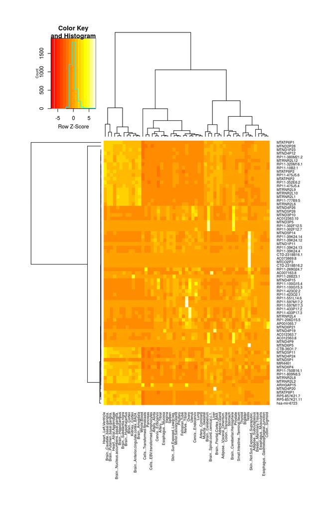

Heatmap of all expressed genes normalized by row (to see the different expression profile of each gene for the different tissues).

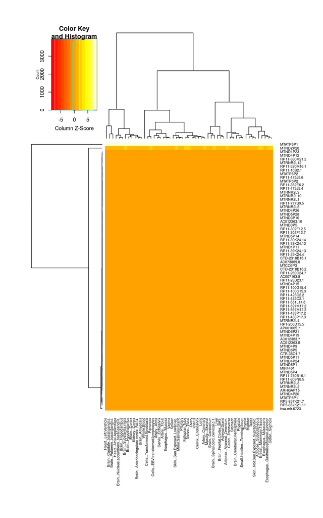

Heatmap of all expressed genes normalized by column (to see the different expression profile of the different gene for each tissue).

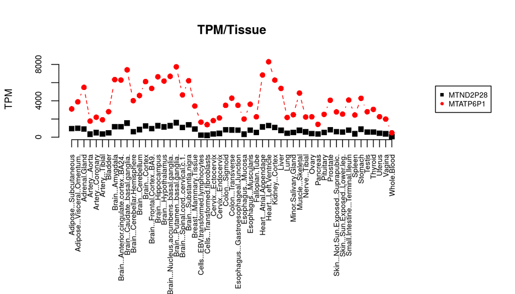

Graphical representation: expression profile of hight expressed genes (>=1000 TMP).

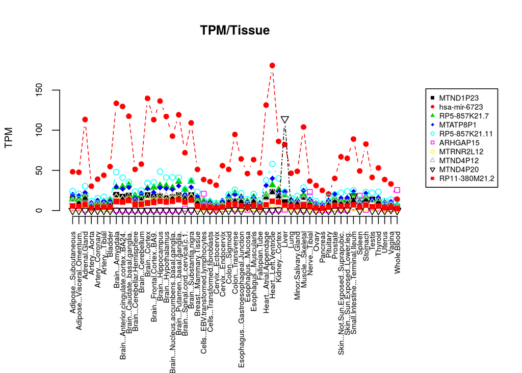

Graphical representation: expression profile of medium expressed genes (between 10 and 1000 TMP).

Of the 453 of our set of genes included in GTEx Portal, 73 are expressed in at least, one tissue (with >= 0.5 TPM). But the [EMBL-EBI Expression Atlas](https://www.ebi.ac.uk/gxa) classified genes in: - low expressed (between 0.5 and 10 TPM), - medium expressed (>=10 to 1000 TPM) and - high expressed (more than 1000 TPM).

In total, we have 2 high expressed (Figure) and 10 genes medium expressed (Figure)

## 6.9 File 11: “FINAL_OUTPUT_TABLE.txt”

Finally, the final table `FINAL_OUTPUT_TABLE.txt` will include relevant information from all the analysis perform in this Dynamic Report. The first 6 lines of our finall document will be:

The dimensions of File 11 are: 1032, 76

```
##            id localization chr start_n  end_n mt start_mt end_mt
## 1 NUMT_01.001     intronic   1  564461 570304 mt     3911   9755
## 2 NUMT_01.001     intronic   1  564461 570304 mt     3911   9755
## 3 NUMT_01.001     intronic   1  564461 570304 mt     3911   9755
## 4 NUMT_01.001     intronic   1  564461 570304 mt     3911   9755
## 5 NUMT_01.001     intronic   1  564461 570304 mt     3911   9755
## 6 NUMT_01.001     intronic   1  564461 570304 mt     3911   9755
##   hgnc_symbol  Description gene_biotype name_1006 ensembl_gene_id_version
## 1    MTND1P23     MTND1P23   pseudogene      <NA>       ENSG00000225972.1
## 2    MTND2P28     MTND2P28   pseudogene      <NA>       ENSG00000225630.1
## 3        <NA> hsa-mir-6723   pseudogene      <NA>       ENSG00000237973.1
## 4        <NA> RP5-857K21.7   pseudogene      <NA>       ENSG00000229344.1
## 5    MTATP8P1     MTATP8P1   pseudogene      <NA>       ENSG00000240409.1
## 6    MTATP6P1     MTATP6P1   pseudogene      <NA>       ENSG00000248527.1
##   transcript_count tissue_means         sum GTEx_gene_id_version
```

[output cut: 146 more lines]

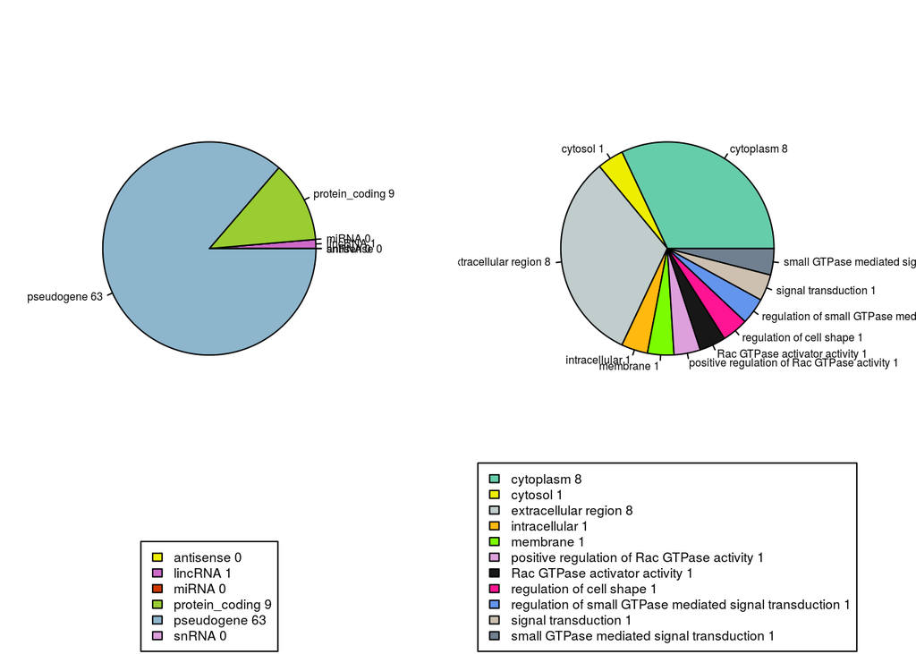

Gene biotype and GO term annotated for our list of expressed genes.

# 7 References

Boogaart, Paul van den, John Samallo, and Etienne Agsteribbe. 1982. “Similar Genes for a Mitochondrial Atpase Subunit in the Nuclear and Mitochondrial Genomes of Neurospora Crassa.” *Nature* 298 (5870). Nature Publishing Group: 187.

Ramos, Amanda, Elena Barbena, Ligia Mateiu, María del Mar González, Quim Mairal, Manuela Lima, Rafael Montiel, Maria Pilar Aluja, and Cristina Santos. 2011. “Nuclear Insertions of Mitochondrial Origin: Database Updating and Usefulness in Cancer Studies.” *Mitochondrion* 11 (6). Elsevier: 946–53.

Tsuzuki, Teruhisa, Hisayuki Nomiyama, Chiaki Setoyama, Shuichiro Maeda, and Kazunori Shimada. 1983. “Presence of Mitochondrial-Dna-Like Sequences in the Human Nuclear Dna.” *Gene* 25 (2). Elsevier: 223–29.

```r
# General knitr options for RMarkdown ----
knitr::opts_chunk$set(external=TRUE, warning=FALSE, message=FALSE,
                      fig.align='center', fig.pos='H')
# Setting working directory ----
## IN R-STUDIO:
### Session --> Set working directory --> Choose directory
## WORKING DIRECTORY (THIS FOLDER):
library(rstudioapi)
current_path <- getActiveDocumentContext()$path
setwd(dirname(current_path))
getwd() # to show the pathway

######## PART 1: Scripts from Dynamic_report_TFM.Rmd ##########

# Installing package if needed ----
list.of.packages <- c("rstudioapi", "dplyr", "xlsx", "rJava", "gplots",
                      "devtools", "ggplot2")
new.packages <- list.of.packages[!(list.of.packages %in%
                                     installed.packages()[,"Package"])]
if(length(new.packages)) install.packages(new.packages)
# Conneting with Bioconductor ----
source("https://bioconductor.org/biocLite.R")
# Installing & loading Bioconductor packages ----
biocLite()
biocLite("biomaRt")
## If biocLite("biomaRt") do not work:
### LINUX COMAND LINE: sudo apt-get install r-bioc-biomart
# Uploading .csv input file ----
numts_coord <- read.csv(file=params$file1, sep = ",", header = TRUE)
str(numts_coord, vec.len = 1)
head(numts_coord)
# The biomaRt package ----
library("biomaRt")
citation("biomaRt") # Package citation
## Preparing Package ‘biomaRt'
gene_mart = useMart(biomart="ENSEMBL_MART_ENSEMBL",
                    host="grch37.ensembl.org",
                    path="/biomart/martservice",
                    dataset="hsapiens_gene_ensembl")

listMarts(gene_mart) # ensembl version used
## Creating "All_attributes.txt" and "All_filters.txt" with all options:
All_attributes <- listAttributes(gene_mart)
All_filters <- listFilters(gene_mart)

write.table(All_attributes, file = "All_attributes.txt", sep = "\t",
            row.names = FALSE, quote = FALSE)
write.table(All_filters, file = "All_filters.txt", sep = "\t",
            row.names = FALSE, quote = FALSE)
# Extracting all genes within NUMTs coordinates ----
library(plyr); library(dplyr)

## Adapting coordenates to download attributes
numts_coord$coord_n <- do.call(paste, c(numts_coord[,2:4], sep = ":"))
numts_vector <-as.vector(t(numts_coord$coord_n))
id <-as.vector(t(numts_coord$id))

## Setting attributes and filters
### Our attributes
attributes_gene = c("chromosome_name", "start_position", "end_position", "strand",
                    "hgnc_symbol", "ensembl_gene_id_version","ensembl_gene_id",
                    "transcript_count")

## Getting values: gene_results.txt (loop)

gene_results <- numeric(0)
i <- 1

for (i in 1:length(numts_vector)) {
  b<-i

  gene_results_b = getBM(attributes_gene,
                         filters = c("chromosomal_region"),
                         values = list(chromosomal_region=numts_vector[b]),
                         mart = gene_mart)

  if (length(gene_results_b[,1]) == 0) {
    gene_results <- rbind(gene_results, c(rep("", length(attributes_gene)),
                                          do.call(paste, list(numts_coord[b,1]))))
  } else {
    gene_results_b$id <- do.call(paste, list(numts_coord[b,1]))
    gene_results <- rbind(gene_results, gene_results_b)
  }

  i <- i + 1
}

gene_results[gene_results==""]  <- NA

## Reordering columns (gene_results.txt)

gene_results <- gene_results %>% dplyr::select("id", everything())

## Sorting results (gene_results.txt)
gene_results <- gene_results[order(gene_results$id,
                                   gene_results$chromosome_name,
                                   gene_results$start_position),]

## Saving the results (gene_results.txt)
write.table(gene_results, file = "gene_results.txt", sep = "\t",
            quote = FALSE, row.names = FALSE)
## Uploading intermediate documents
gene_results <- read.table("gene_results.txt", header = TRUE, sep = "\t")
summary(gene_results)
# Extracting all genes upstream and downstream from the NUMTs coordinates ----
library(plyr); library(dplyr)

  ## Indicating new coordinates
up_start <- numts_coord[3] - 1000
up_end <- numts_coord[3] - 100
down_start <- numts_coord[4] + 100
down_end <- numts_coord[4] + 1000

up_numts_coord <- data.frame(numts_coord$id,
                             numts_coord$chr,
                             up_start,
                             up_end)
down_numts_coord <- data.frame(numts_coord$id,
                               numts_coord$chr,
                               down_start,
                               down_end)

  ## Adapting coordenates to download attributes
up_numts_coord$coord_n <- do.call(paste, c(up_numts_coord[,2:4], sep = ":"))
up_numts_vector <-as.vector(t(up_numts_coord$coord_n))
down_numts_coord$coord_n <- do.call(paste, c(down_numts_coord[,2:4], sep = ":"))
down_numts_vector <-as.vector(t(down_numts_coord$coord_n))

## Getting values: up_gene_results.txt (loop)

up_gene_results <- numeric(0)
i <- 1

for (i in 1:length(up_numts_vector)) {
  b<-i

  up_gene_results_b = getBM(attributes_gene,
                         filters = c("chromosomal_region"),
                         values = list(chromosomal_region=up_numts_vector[b]),
                         mart = gene_mart)

  if (length(up_gene_results_b[,1]) == 0) {
    up_gene_results <- rbind(up_gene_results,
                             c(rep("", length(attributes_gene)),
                               do.call(paste, list(numts_coord[b,1]))))
  } else {
    up_gene_results_b$id <- do.call(paste, list(numts_coord[b,1]))
    up_gene_results <- rbind(up_gene_results, up_gene_results_b)
  }

  i <- i + 1
}

up_gene_results[up_gene_results==""]  <- NA

### Reordering columns (up_gene_results.txt)
up_gene_results <- up_gene_results %>%  dplyr::select("id", everything())

### Sorting results (up_gene_results.txt)
up_gene_results <- up_gene_results[order(up_gene_results$id,
                                         up_gene_results$chromosome_name,
                                         up_gene_results$start_position),]
```

```r
### Saving the results (up_gene_results.txt)
write.table(up_gene_results, file = "up_gene_results.txt", sep = "\t",
            quote = FALSE, row.names = FALSE)


## Getting values: down_gene_results.txt (loop)

down_gene_results <- numeric(0)
i <- 1

for (i in 1:length(down_numts_vector)) {
  b<-i

  down_gene_results_b = getBM(attributes_gene,
                         filters = c("chromosomal_region"),
                         values = list(chromosomal_region=down_numts_vector[b]),
                         mart = gene_mart)

  if (length(down_gene_results_b[,1]) == 0) {
    down_gene_results <- rbind(down_gene_results,
                             c(rep("", length(attributes_gene)),
                               do.call(paste, list(numts_coord[b,1]))))
  } else {
    down_gene_results_b$id <- do.call(paste, list(numts_coord[b,1]))
    down_gene_results <- rbind(down_gene_results, down_gene_results_b)
  }

  i <- i + 1
}

down_gene_results[down_gene_results==""]  <- NA

### Reordering columns (down_gene_results.txt)
down_gene_results <- down_gene_results %>% dplyr::select("id", everything())

### Sorting results (down_gene_results.txt)
down_gene_results <- down_gene_results[order(down_gene_results$id,
                                             down_gene_results$chromosome_name,
                                             down_gene_results$start_position),]

### Saving the results (down_gene_results.txt)
write.table(down_gene_results, file = "down_gene_results.txt", sep = "\t",
            quote = FALSE, row.names = FALSE)
## Uploading intermediate documents
up_gene_results <- read.table("up_gene_results.txt", header = TRUE, sep = "\t")
str(up_gene_results, vec.len = 1)

down_gene_results <- read.table("down_gene_results.txt", header = TRUE, sep = "\t")
str(down_gene_results, vec.len = 1)

# Extracting genes originated by NUMT insertions ----
## Total genes
TOTAL_GENES <- as.character(na.omit(unique(gene_results$ensembl_gene_id_version)))
UP_GENES <- as.character(na.omit(unique(up_gene_results$ensembl_gene_id_version)))
DOWN_GENES <- as.character(na.omit(unique(down_gene_results$ensembl_gene_id_version)))
## Common genes present in all three list of genes
## (gene_results, upstream and downstream)
library(plyr); library(dplyr)
data_joined <- dplyr::inner_join(up_gene_results, down_gene_results)

## Creating column "Localization"
data_joined$localization <- data_joined$ensembl_gene_id
data_joined$localization[!is.na(data_joined$localization)] <- "intronic"
data_joined$localization[is.na(data_joined$localization)] <- "intergenic"

## Genes in gene_results.txt but not in upper and downstream regions
int_gene_results <- anti_join(gene_results, data_joined)
## Saving genes.txt
genes <- as.character(na.omit(unique(int_gene_results$ensembl_gene_id)))

write.table(genes, file="genes.txt",col.names = F, sep="\t",quote=F,row.names=F)
## Uploading intermediate documents
genes <- read.table("genes.txt", header = FALSE, sep = "\t")

table_numts_genes <- gene_results[gene_results$ensembl_gene_id
                                  %in% genes$V1,]

chrom <- (unique(table_numts_genes[c(2,7)]))

# Number of genes per chromosome
table(chrom[1])
# GO terms (go_results.txt) ----
## Setting attributes and filters
 ### Our attributes
attributes_go = c("hgnc_symbol", "ensembl_gene_id_version",
                  "go_id", "name_1006", "definition_1006")

go_results = getBM(attributes_go,
                   filters = c("ensembl_gene_id"),
                   values = list(ensembl_gene_id=genes$V1),
                   mart = gene_mart)

go_results[go_results==""]  <- NA

go_results <- go_results[order(go_results$ensembl_gene_id_version, go_results$go_id),]

go_results <- go_results[complete.cases(go_results$name_1006), ]

write.table(go_results, file = "go_results.txt", sep = "\t",
            quote = FALSE, row.names = FALSE)
go_results <-read.table("go_results.txt", header = TRUE, sep = "\t")
go_results[c(1:4)]
## Plotting GO results
par(mfrow=c(1,2))
par(mar = c(8.5, 2.5, 2.5, 4), xpd=TRUE)

ensembl_go <- na.omit(unique(go_results[c("hgnc_symbol", "name_1006")]))

ensembl_go <- ensembl_go[complete.cases(ensembl_go), ]

colors = c("aquamarine3","yellow2","azure3",
          "darkgoldenrod1", "lawngreen", "plum",
          "gray9","deeppink1","cornflowerblue",
          "antiquewhite3", "slategrey", "tomato")

### Bar plot
barplot(table(ensembl_go$name_1006), las=2, cex.main = 1.2,
        cex.axis = 0.7, cex = 0.7,  col = colors)


### pie chart
counts = table(ensembl_go$name_1006)  ## get counts
labs = paste(levels(ensembl_go$name_1006), counts)  ## create labels
pie(counts, labels = labs, col = colors, cex=0.5)  ## plot
legend("bottom", inset=c(0,-0.6), labs, cex=0.6, fill=colors)
# phenotype_results.txt ----
## Setting attributes and filters
### Our attributes
attributes_phenotype = c("hgnc_symbol", "ensembl_gene_id_version", "transcript_count",
                         "gene_biotype", "description")

## Getting values: phenotype_results ----

phenotype_results = getBM(attributes_phenotype,
                              filters = c("ensembl_gene_id"),
                              values = list(ensembl_gene_id=genes$V1),
                              mart = gene_mart)

# class(phenotype_results) # data.frame
phenotype_results[phenotype_results==""]  <- NA

phenotype_results <- phenotype_results[order(phenotype_results$ensembl_gene_id_version),]

write.table(phenotype_results, file = "phenotype_results.txt", sep = "\t",
            quote = FALSE, row.names = FALSE)

## Uploading intermediate documents
phenotype_results <-read.table("phenotype_results.txt",
                               header = TRUE, sep = "\t")
summary(phenotype_results)
## Plotting Gene biotype results
par(mfrow=c(1,2))
par(mar = c(6, 2.5, 2.5, 2.5), xpd=TRUE)

ensembl_biotype <- na.omit(unique(phenotype_results[c("ensembl_gene_id_version",
                                                      "gene_biotype")]))

colors = c("yellow2","orchid3","orangered3",
          "olivedrab3", "lightskyblue3", "plum")
```

```r
### Bar plot
barplot(table(ensembl_biotype$gene_biotype), las=2, cex.main = 1.2,
        cex.axis = 0.7, cex = 0.7,  col = colors)

### pie chart
counts = table(ensembl_biotype$gene_biotype)  ## get counts
labs = paste(levels(ensembl_biotype$gene_biotype), counts)  ## create labels
pie(counts, labels = labs, col = colors, cex=0.5)  ## plot
legend("bottom", inset=c(0, -0.2), labs, cex=0.6, fill=colors)
# EXPRESSION STUDY ----
## Uploading GTEx means in TPM
GTEx_mean_tpm <-
  read.table(file = params$file2, skip = 2,
             header = TRUE, sep = "\t")
## Creating mean_tpm_GTEx.txt
library(plyr); library(dplyr)

GTEx_tpm <- GTEx_mean_tpm
colnames(GTEx_tpm)[1] <- "GTEx_gene_id_version"

gene_id <- GTEx_mean_tpm$gene_id
GTEx_genes <- numeric(0)
for (i in 1:length(GTEx_mean_tpm$gene_id)){
    x <- unlist(strsplit(as.character(GTEx_mean_tpm[i,1]), split='.', fixed=TRUE))[1]
    GTEx_genes <- rbind(GTEx_genes, x)
}

GTEx_mean_tpm$gene_id <- GTEx_genes

mean_tpm_fromGTEx <- numeric(0)
for (i in 1:nrow(genes)){
    y <- subset(GTEx_mean_tpm, gene_id == genes[i,1])
    mean_tpm_fromGTEx <- rbind(mean_tpm_fromGTEx, y)
}

tissue_means <- rowMeans(mean_tpm_fromGTEx[,3:length(mean_tpm_fromGTEx)])
mean_tpm_fromGTEx$tissue_means <- tissue_means

mean_tpm_fromGTEx$sum <- rowSums(mean_tpm_fromGTEx[,3:length(mean_tpm_fromGTEx)])

mean_tpm_fromGTEx$gene_id <- as.character(mean_tpm_fromGTEx$gene_id)

mean_tpm_GTEx <- dplyr::inner_join(mean_tpm_fromGTEx,
                                GTEx_tpm)

mean_tpm_GTEx <- mean_tpm_GTEx %>% dplyr::select("gene_id", "GTEx_gene_id_version",
                                                 everything())
colnames(mean_tpm_GTEx)[1] <- "ensembl_gene_id"
str(mean_tpm_GTEx)

# Saving results
write.table(mean_tpm_GTEx, file = "mean_tpm_GTEx.txt", sep = "\t",
            quote = FALSE, row.names = FALSE)
## Uploading intermediate documents
mean_tpm_GTEx <- read.table("mean_tpm_GTEx.txt", header = TRUE,
                                sep = "\t", dec = ".")
# subset_expressed.txt ----
## Creating subset of genes with >= 0.5 TPM (expressed)
GTEx <- mean_tpm_GTEx
subset_expressed <- subset(GTEx, GTEx[4] >= 0.5 | GTEx[5] >= 0.5 | GTEx[6] >= 0.5 |
                             GTEx[7] >= 0.5 | GTEx[8] >= 0.5 | GTEx[9] >= 0.5 |
                             GTEx[10] >= 0.5 |GTEx[11] >= 0.5 | GTEx[12] >= 0.5 |
                             GTEx[13] >= 0.5 | GTEx[14] >= 0.5 | GTEx[15] >= 0.5 |
                             GTEx[16] >= 0.5 | GTEx[17] >= 0.5 | GTEx[18] >= 0.5 |
                             GTEx[19] >= 0.5 | GTEx[20] >= 0.5 | GTEx[21] >= 0.5 |
                             GTEx[22] >= 0.5 | GTEx[23] >= 0.5 | GTEx[24] >= 0.5 |
                             GTEx[25] >= 0.5 | GTEx[26] >= 0.5 | GTEx[27] >= 0.5 |
                             GTEx[28] >= 0.5 | GTEx[29] >= 0.5 | GTEx[30] >= 0.5 |
                             GTEx[31] >= 0.5 | GTEx[32] >= 0.5 | GTEx[33] >= 0.5 |
                             GTEx[34] >= 0.5 | GTEx[35] >= 0.5 | GTEx[36] >= 0.5 |
                             GTEx[37] >= 0.5 | GTEx[38] >= 0.5 | GTEx[39] >= 0.5 |
                             GTEx[40] >= 0.5 | GTEx[41] >= 0.5 | GTEx[42] >= 0.5 |
                             GTEx[43] >= 0.5 | GTEx[44] >= 0.5 | GTEx[45] >= 0.5 |
                             GTEx[46] >= 0.5 | GTEx[47] >= 0.5 | GTEx[48] >= 0.5 |
                             GTEx[49] >= 0.5 | GTEx[50] >= 0.5 | GTEx[51] >= 0.5 |
                             GTEx[52] >= 0.5 | GTEx[53] >= 0.5 | GTEx[54] >= 0.5 |
                             GTEx[55] >= 0.5 | GTEx[56] >= 0.5 | GTEx[57] >= 0.5 )

## saving results
write.table(subset_expressed, file = "subset_expressed.txt", sep = "\t",
            quote = FALSE, row.names = FALSE)
## Uploading intermediate documents
subset_expressed <- read.table("subset_expressed.txt", header = TRUE,
                                sep = "\t", dec = ".")
summary(subset_expressed[c(4:ncol(subset_expressed))])
## Heatmap of all expressed genes.
library(gplots)
par(oma=c(10,4,4,2))
subset_mean_tpm <- subset_expressed
subset_mean_tpm[1] <- NULL
rownames(subset_mean_tpm) <- subset_mean_tpm$Description
subset_mean_tpm[1] <- NULL
subset_mean_tpm[1] <- NULL

heatmap.2(data.matrix(subset_mean_tpm[1:53]), trace='none', scale = "row",
          cexRow=0.6, cexCol = 0.6)

## Heatmap of all expressed genes.
library(gplots)
par(oma=c(10,4,4,2))
subset_mean_tpm <- subset_expressed
subset_mean_tpm[1] <- NULL
rownames(subset_mean_tpm) <- subset_mean_tpm$Description
subset_mean_tpm[1] <- NULL
subset_mean_tpm[1] <- NULL

heatmap.2(data.matrix(subset_mean_tpm[1:53]), trace='none', scale = "column",
          cexRow=0.6, cexCol = 0.6)

## Graphical representation: expression profile of
## hight expressed genes (>=1000 TMP)

par(mar = c(10.5, 4, 4, 7.5), xpd=TRUE)
GTEx1 <- subset_mean_tpm
subset_mean_tpm2 <- subset(GTEx1, GTEx1[1] >= 1000.0 |GTEx1[2] >= 1000.0 |
                             GTEx1[3] >= 1000.0 | GTEx1[4] >= 1000.0 |
                             GTEx1[5] >= 1000.0 | GTEx1[6] >= 1000.0 |
                             GTEx1[7] >= 1000.0 | GTEx1[8] >= 1000.0 |
                             GTEx1[9] >= 1000.0 | GTEx1[10] >= 1000.0 |
                             GTEx1[11] >= 1000.0 | GTEx1[12] >= 1000.0 |
                             GTEx1[13] >= 1000.0 | GTEx1[14] >= 1000.0 |
                             GTEx1[15] >= 1000.0 | GTEx1[16] >= 1000.0 |
                             GTEx1[17] >= 1000.0 | GTEx1[18] >= 1000.0 |
                             GTEx1[19] >= 1000.0 | GTEx1[20] >= 1000.0 |
                             GTEx1[21] >= 1000.0 | GTEx1[22] >= 1000.0 |
                             GTEx1[23] >= 1000.0 | GTEx1[24] >= 1000.0 |
                             GTEx1[25] >= 1000.0 | GTEx1[26] >= 1000.0 |
                             GTEx1[27] >= 1000.0 | GTEx1[28] >= 1000.0 |
                             GTEx1[29] >= 1000.0 | GTEx1[30] >= 1000.0 |
                             GTEx1[31] >= 1000.0 | GTEx1[32] >= 1000.0 |
                             GTEx1[33] >= 1000.0 | GTEx1[34] >= 1000.0 |
                             GTEx1[35] >= 1000.0 | GTEx1[36] >= 1000.0 |
                             GTEx1[37] >= 1000.0 | GTEx1[38] >= 1000.0 |
                             GTEx1[39] >= 1000.0 | GTEx1[40] >= 1000.0 |
                             GTEx1[41] >= 1000.0 | GTEx1[42] >= 1000.0 |
                             GTEx1[43] >= 1000.0 | GTEx1[44] >= 1000.0 |
                             GTEx1[45] >= 1000.0 | GTEx1[46] >= 1000.0 |
                             GTEx1[47] >= 1000.0 | GTEx1[48] >= 1000.0 |
                             GTEx1[49] >= 1000.0 | GTEx1[50] >= 1000.0 |
                             GTEx1[51] >= 1000.0 | GTEx1[52] >= 1000.0 |
                             GTEx1[53] >= 1000.0 )
matplot(t(data.matrix(subset_mean_tpm2[1:53])), type = "b",
        col = c(1:ncol(subset_mean_tpm2)),
        cex.main = 1, cex.lab = 0.8,    ylab = "TPM", pch=c(15:18,21:25),
        main = "TPM/Tissue", axes = FALSE)
axis(2, cex.axis=0.7)
axis(side=1,at=1:ncol(subset_mean_tpm2[1:53]), cex.axis=0.6, las = 2,
     labels=colnames(subset_mean_tpm2[1:53]))
```

```r
legend("right", inset=c(-0.25, 1), legend=rownames(subset_mean_tpm2[1:53]),
       col=c(1:ncol(subset_mean_tpm2)),pch= c(15:18,21:25),
       cex = 0.6, bg= ("white"), horiz=F)

## Graphical representation: expression profile of
## medium expressed genes (between 10 and 1000 TMP)

subset_mean_tpm3 <- subset(GTEx1, GTEx1[1] >= 10.0 |GTEx1[2] >= 10.0 |
                             GTEx1[3] >= 10.0 | GTEx1[4] >= 10.0 |
                             GTEx1[5] >= 10.0 | GTEx1[6] >= 10.0 |
                             GTEx1[7] >= 10.0 | GTEx1[8] >= 10.0 |
                             GTEx1[9] >= 10.0 | GTEx1[10] >= 10.0 |
                             GTEx1[11] >= 10.0 | GTEx1[12] >= 10.0 |
                             GTEx1[13] >= 10.0 | GTEx1[14] >= 10.0 |
                             GTEx1[15] >= 10.0 | GTEx1[16] >= 10.0 |
                             GTEx1[17] >= 10.0 | GTEx1[18] >= 10.0 |
                             GTEx1[19] >= 10.0 | GTEx1[20] >= 10.0 |
                             GTEx1[21] >= 10.0 | GTEx1[22] >= 10.0 |
                             GTEx1[23] >= 10.0 | GTEx1[24] >= 10.0 |
                             GTEx1[25] >= 10.0 | GTEx1[26] >= 10.0 |
                             GTEx1[27] >= 10.0 | GTEx1[28] >= 10.0 |
                             GTEx1[29] >= 10.0 | GTEx1[30] >= 10.0 |
                             GTEx1[31] >= 10.0 | GTEx1[32] >= 10.0 |
                             GTEx1[33] >= 10.0 | GTEx1[34] >= 10.0 |
                             GTEx1[35] >= 10.0 | GTEx1[36] >= 10.0 |
                             GTEx1[37] >= 10.0 | GTEx1[38] >= 10.0 |
                             GTEx1[39] >= 10.0 | GTEx1[40] >= 10.0 |
                             GTEx1[41] >= 10.0 | GTEx1[42] >= 10.0 |
                             GTEx1[43] >= 10.0 | GTEx1[44] >= 10.0 |
                             GTEx1[45] >= 10.0 | GTEx1[46] >= 10.0 |
                             GTEx1[47] >= 10.0 | GTEx1[48] >= 10.0 |
                             GTEx1[49] >= 10.0 | GTEx1[50] >= 10.0 |
                             GTEx1[51] >= 10.0 | GTEx1[52] >= 10.0 |
                             GTEx1[53] >= 10.0 )
subset_mean_tpm3 <- subset_mean_tpm3[!rownames(subset_mean_tpm3) %in%
                                       rownames(subset_mean_tpm2), ]

par(mar = c(10.5, 4, 4, 7.5), xpd=TRUE)
matplot(t(data.matrix(subset_mean_tpm3[1:53])), type = "b",
        col = c(1:ncol(subset_mean_tpm3)),
        cex.main = 1, cex.lab = 0.8,    ylab = "TPM", pch=c(15:18,21:25),
        main = "TPM/Tissue", axes = FALSE)
axis(2, cex.axis=0.7)
axis(side=1,at=1:ncol(subset_mean_tpm3[1:53]), cex.axis=0.6, las = 2,
     labels=colnames(subset_mean_tpm3[1:53]))

legend("right", inset=c(-0.25, 1), legend=rownames(subset_mean_tpm3[1:53]),
       col=c(1:ncol(subset_mean_tpm3)),pch= c(15:18,21:25), cex = 0.6,
       bg= ("white"), horiz=F)

# FINAL TABLE: FINAL_OUTPUT_TABLE.txt ----
library(plyr); library(dplyr)

## Cheking genes and creating table
table_numts_genes <- gene_results[gene_results$ensembl_gene_id
                                  %in% genes$V1,]

str(table_numts_genes)
length(unique(table_numts_genes$ensembl_gene_id))
summary(table_numts_genes)

table_numts_genes <- dplyr::full_join(numts_coord,
                         table_numts_genes)

table_numts_genes <- dplyr::full_join(data_joined[c("id", "localization")],
                         table_numts_genes)
table_numts_genes$localization[is.na(table_numts_genes$localization)] <- "partial_gene"
table_numts_genes <- dplyr::full_join(phenotype_results[c("ensembl_gene_id_version",
                                             "gene_biotype", "description")],
                               table_numts_genes)

table_numts_go <- dplyr::full_join(go_results[c("ensembl_gene_id_version",
                                      "name_1006")],
                         table_numts_genes)

table_numts_exp <- dplyr::full_join(mean_tpm_GTEx,
                         table_numts_go)

table_numts <- table_numts_exp %>% dplyr::select("id", "localization", "chr",
                                                 "start_n", "end_n", "mt",
                                                 "start_mt", "end_mt",
                                                 "hgnc_symbol", "Description",
                                                 "gene_biotype", "name_1006",
                                                 "ensembl_gene_id_version",
                                                 "transcript_count",
                                                 "tissue_means", "sum",
                                                 everything())

## Removing columns
table_numts$ensembl_gene_id = NULL

## Sorting results (gene_results.txt) ----

table_numts <- table_numts[order(table_numts$id,
                                 table_numts$chr,
                                 table_numts$start_n,
                                 table_numts$start_position),]

table_numts <- table_numts[!duplicated(table_numts), ]

## Saving results
write.table(table_numts, file="FINAL_OUTPUT_TABLE.txt",
            sep="\t",quote=F,row.names=F)
## Uploading intermediate documents
table_numts <- read.table("FINAL_OUTPUT_TABLE.txt", header = TRUE, sep = "\t")
## Showing 6 first data from FINAL TABLE "FINAL_OUTPUT_TABLE.txt"
head(table_numts)
library(plyr); library(dplyr)

only_expressed <- table_numts[table_numts$ensembl_gene_id
                                  %in% subset_expressed$GTEx_gene_id_version,]
## Plotting Gene biotype results
par(mfrow=c(1,2))
par(mar = c(8.5, 2.5, 2.5, 4), xpd=TRUE)
ensembl_biotype_ex <- na.omit(unique(only_expressed[c("ensembl_gene_id_version",
                                                      "gene_biotype")]))

ensembl_go_ex <- na.omit(unique(only_expressed[c("ensembl_gene_id_version",
                                                      "name_1006")]))
colors = c("yellow2","orchid3","orangered3",
          "olivedrab3", "lightskyblue3", "plum")

### pie chart
counts = table(ensembl_biotype_ex$gene_biotype)  ## get counts
labs = paste(levels(ensembl_biotype$gene_biotype), counts)  ## create labels
pie(counts, labels = labs, col = colors, cex=0.5)  ## plot
legend("bottom", inset=c(0,-0.6), labs, cex=0.6, fill=colors)
```

```r
## Plotting GO results

ensembl_go <- ensembl_go_ex[complete.cases(ensembl_go_ex), ]

colors = c("aquamarine3","yellow2","azure3",
          "darkgoldenrod1", "lawngreen", "plum",
          "gray9","deeppink1","cornflowerblue",
          "antiquewhite3", "slategrey", "tomato")

### pie chart
counts = table(ensembl_go$name_1006)  ## get counts
labs = paste(levels(ensembl_go$name_1006), counts)  ## create labels
pie(counts, labels = labs, col = colors, cex=0.5)  ## plot
legend("bottom", inset=c(0,-0.6), labs, cex=0.6, fill=colors)

# # # # # # # # # # # # sessionInf() # # # # # # # # # # # #
devtools::session_info()
```

```
##  setting  value
##  version  R version 3.4.4 (2018-03-15)
##  system   x86_64, linux-gnu
##  ui       X11
##  language en_US
##  collate  en_US.UTF-8
##  tz       Europe/Madrid
##  date     2018-06-06
##
##  package       * version  date       source
##  AnnotationDbi   1.40.0   2018-04-19 Bioconductor
##  assertthat      0.2.0    2017-04-11 CRAN (R 3.4.4)
##  backports       1.1.2    2017-12-13 CRAN (R 3.4.4)
##  base          * 3.4.4    2018-03-16 local
##  bindr           0.1.1    2018-03-13 CRAN (R 3.4.4)
##  bindrcpp        0.2.2    2018-03-29 CRAN (R 3.4.4)
##  Biobase         2.38.0   2018-04-25 Bioconductor
##  BiocGenerics    0.24.0   2018-04-19 Bioconductor
##  BiocInstaller * 1.28.0   2018-04-19 Bioconductor
##  biomaRt       * 2.34.2   2018-06-06 Bioconductor
##  bit             1.1-13   2018-05-15 CRAN (R 3.4.4)
##  bit64           0.9-7    2017-05-08 CRAN (R 3.4.4)
##  bitops          1.0-6    2013-08-17 CRAN (R 3.4.4)
##  blob            1.1.1    2018-03-25 CRAN (R 3.4.4)
##  caTools         1.17.1   2014-09-10 CRAN (R 3.4.4)
##  compiler        3.4.4    2018-03-16 local
##  curl            3.2      2018-03-28 CRAN (R 3.4.4)
##  datasets      * 3.4.4    2018-03-16 local
##  DBI             1.0.0    2018-05-02 CRAN (R 3.4.4)
##  devtools        1.13.5   2018-02-18 CRAN (R 3.4.4)
##  digest          0.6.15   2018-01-28 CRAN (R 3.4.4)
##  dplyr         * 0.7.5    2018-05-19 CRAN (R 3.4.4)
##  evaluate        0.10.1   2017-06-24 CRAN (R 3.4.4)
##  gdata           2.18.0   2017-06-06 CRAN (R 3.4.4)
##  glue            1.2.0    2017-10-29 CRAN (R 3.4.4)
##  gplots        * 3.0.1    2016-03-30 CRAN (R 3.4.4)
##  graphics      * 3.4.4    2018-03-16 local
##  grDevices     * 3.4.4    2018-03-16 local
##  gtools          3.5.0    2015-05-29 CRAN (R 3.4.4)
##  highr           0.6      2016-05-09 CRAN (R 3.4.4)
```

[output cut: 19 more lines]

```
##  rmarkdown       1.9      2018-03-01 CRAN (R 3.4.4)
##  rprojroot       1.3-2    2018-01-03 CRAN (R 3.4.4)
##  RSQLite         2.1.1    2018-05-06 CRAN (R 3.4.4)
##  S4Vectors       0.16.0   2018-04-19 Bioconductor
##  stats         * 3.4.4    2018-03-16 local
##  stats4          3.4.4    2018-03-16 local
##  stringi         1.2.2    2018-05-02 CRAN (R 3.4.4)
##  stringr         1.3.1    2018-05-10 CRAN (R 3.4.4)
##  tibble          1.4.2    2018-01-22 CRAN (R 3.4.4)
##  tidyselect      0.2.4    2018-02-26 CRAN (R 3.4.4)
##  tools           3.4.4    2018-03-16 local
##  utils         * 3.4.4    2018-03-16 local
##  withr           2.1.2    2018-03-15 CRAN (R 3.4.4)
##  XML             3.98-1.3 2015-06-30 CRAN (R 3.2.1)
##  yaml            2.1.19   2018-05-01 CRAN (R 3.4.4)
```